# Project: Investigate a Dataset - [TMDb movie data]

- Introduction
- Data Wrangling
- Exploratory Data Analysis
- Conclusions
- Limitations

## Introduction

### Dataset Description

This data set contains infoirmation about 10,000 movies collected from The Movie Database (TMDb), including user ratings and revenue. The dataset contains 21 features such as popularity, budget, revenue, genre, release year, and runtime. In addition to other features that will not used in the analysis.

### Question(s) for Analysis

1-First question I will be addressing in this analysis is the relation between the budget of a movie and its revenue, where the budget of the movie will be the independent variable and revenue the dependent variable.

2-Second question for analysis is, what are the most popular genre through the years from 1960 to 2015.

```python
#importing all packages used in the analysis
import numpy as np
import pandas as pd
import seaborn as sns
import math
from scipy import stats
from scipy.stats import linregress
import matplotlib.pyplot as plt
%matplotlib inline
```

```python
# Upgrading pandas to use dataframe.explode() function.
!pip install --upgrade pandas==1.4.3
```

## Data Wrangling

### General Properties

First, we need to check the columns pertinent to analysis for missing, duplicate, or errant values to make sure data is ready for analysis. These columns are release year, budget, revenue, genre, and popularity.

```python
#laoding data into a dataframe
df=pd.read_csv('tmdb-movies.csv')
```

```python
#a quick preview of the data
df.head()
```

|  | id | imdb_id | popularity | budget | revenue | original_title | cast | homepage | director | tagline | ... | overview | runtime | genres | production_companies | release_date | vote_count | vote_average | release_year | budget_adj | revenue_adj |
| --- | --- | --- | --- | --- | --- | --- | --- | --- | --- | --- | --- | --- | --- | --- | --- | --- | --- | --- | --- | --- | --- |
| 0 | 135397 | tt0369610 | 32.985763 | 150000000 | 1513528810 | Jurassic World | Chris Pratt\|Bryce Dallas Howard\|Irrfan Khan\|Vi... | http://www.jurassicworld.com/ | Colin Trevorrow | The park is open. | ... | Twenty-two years after the events of Jurassic ... | 124 | Action\|Adventure\|Science Fiction\|Thriller | Universal Studios\|Amblin Entertainment\|Legenda... | 6/9/15 | 5562 | 6.5 | 2015 | 1.379999e+08 | 1.392446e+09 |
| 1 | 76341 | tt1392190 | 28.419936 | 150000000 | 378436354 | Mad Max: Fury Road | Tom Hardy\|Charlize Theron\|Hugh Keays-Byrne\|Nic... | http://www.madmaxmovie.com/ | George Miller | What a Lovely Day. | ... | An apocalyptic story set in the furthest reach... | 120 | Action\|Adventure\|Science Fiction\|Thriller | Village Roadshow Pictures\|Kennedy Miller Produ... | 5/13/15 | 6185 | 7.1 | 2015 | 1.379999e+08 | 3.481613e+08 |
| 2 | 262500 | tt2908446 | 13.112507 | 110000000 | 295238201 | Insurgent | Shailene Woodley\|Theo James\|Kate Winslet\|Ansel... | http://www.thedivergentseries.movie/#insurgent | Robert Schwentke | One Choice Can Destroy You | ... | Beatrice Prior must confront her inner demons ... | 119 | Adventure\|Science Fiction\|Thriller | Summit Entertainment\|Mandeville Films\|Red Wago... | 3/18/15 | 2480 | 6.3 | 2015 | 1.012000e+08 | 2.716190e+08 |
| 3 | 140607 | tt2488496 | 11.173104 | 200000000 | 2068178225 | Star Wars: The Force Awakens | Harrison Ford\|Mark Hamill\|Carrie Fisher\|Adam D... | http://www.starwars.com/films/star-wars-episod... | J.J. Abrams | Every generation has a story. | ... | Thirty years after defeating the Galactic Empi... | 136 | Action\|Adventure\|Science Fiction\|Fantasy | Lucasfilm\|Truenorth Productions\|Bad Robot | 12/15/15 | 5292 | 7.5 | 2015 | 1.839999e+08 | 1.902723e+09 |
| 4 | 168259 | tt2820852 | 9.335014 | 190000000 | 1506249360 | Furious 7 | Vin Diesel\|Paul Walker\|Jason Statham\|Michelle ... | http://www.furious7.com/ | James Wan | Vengeance Hits Home | ... | Deckard Shaw seeks revenge against Dominic Tor... | 137 | Action\|Crime\|Thriller | Universal Pictures\|Original Film\|Media Rights ... | 4/1/15 | 2947 | 7.3 | 2015 | 1.747999e+08 | 1.385749e+09 |

5 rows × 21 columns

```python
print(df.shape)
```

```
(10866, 21)
```

The data contains 21 features and 10866 rows.

```python
print('The information on the data set is:\n')
print(df.info())
```

```
The information on the data set is:

<class 'pandas.core.frame.DataFrame'>
RangeIndex: 10866 entries, 0 to 10865
Data columns (total 21 columns):
 #   Column                Non-Null Count  Dtype
---  ------                --------------  -----
 0   id                    10866 non-null  int64
 1   imdb_id               10856 non-null  object
 2   popularity            10866 non-null  float64
 3   budget                10866 non-null  int64
 4   revenue               10866 non-null  int64
 5   original_title        10866 non-null  object
 6   cast                  10790 non-null  object
 7   homepage              2936 non-null   object
 8   director              10822 non-null  object
 9   tagline               8042 non-null   object
 10  keywords              9373 non-null   object
 11  overview              10862 non-null  object
 12  runtime               10866 non-null  int64
 13  genres                10843 non-null  object
 14  production_companies  9836 non-null   object
 15  release_date          10866 non-null  object
 16  vote_count            10866 non-null  int64
 17  vote_average          10866 non-null  float64
 18  release_year          10866 non-null  int64
 19  budget_adj            10866 non-null  float64
 20  revenue_adj           10866 non-null  float64
dtypes: float64(4), int64(6), object(11)
memory usage: 1.7+ MB
None
```

```python
#number of missing values in each column
print('The number of missing values in each column:')
df.isnull().sum()
```

```
The number of missing values in each column:
```

```
id                         0
imdb_id                   10
popularity                 0
budget                     0
revenue                    0
original_title             0
cast                      76
homepage                7930
director                  44
tagline                 2824
keywords                1493
overview                   4
runtime                    0
genres                    23
production_companies    1030
release_date               0
vote_count                 0
vote_average               0
release_year               0
budget_adj                 0
revenue_adj                0
dtype: int64
```

```python
#number of duplicate data
print('The number of duplicate values is:')
print(df.duplicated().sum())
```

```
The number of duplicate values is:
1
```

It appears some columns have some missing values. We need to drop the rows with missing values and duplicate data in columns pertinent to analysis. However, we need to drop columns not used in the anaysis first.

### Data Cleaning

```python
#dropping duplicated rows
df.drop_duplicates(inplace=True)
```

```python
#checking again for duplicates
df.duplicated().sum()
```

```
0
```

The duplicate entry was removed.

```python
#dropping columns that will not be used in the analysis
df.drop(columns = ['id','imdb_id','original_title','cast','vote_count','vote_average','homepage','director','tagline','keywords','overview','production_companies','release_date','budget_adj','revenue_adj'], inplace = True)
```

```python
print(df.info())
```

```
<class 'pandas.core.frame.DataFrame'>
Int64Index: 10865 entries, 0 to 10865
Data columns (total 6 columns):
 #   Column        Non-Null Count  Dtype
---  ------        --------------  -----
 0   popularity    10865 non-null  float64
 1   budget        10865 non-null  int64
 2   revenue       10865 non-null  int64
 3   runtime       10865 non-null  int64
 4   genres        10842 non-null  object
 5   release_year  10865 non-null  int64
dtypes: float64(1), int64(4), object(1)
memory usage: 594.2+ KB
None
```

Now, that we dropped columns not used in the analysis, we can start clearing missing values.

```python
#there is only a few missing values in the genres column so we can drop them
df.dropna(subset = ['genres'],inplace = True)
```

```python
df.info()
```

```
<class 'pandas.core.frame.DataFrame'>
Int64Index: 10842 entries, 0 to 10865
Data columns (total 6 columns):
 #   Column        Non-Null Count  Dtype
---  ------        --------------  -----
 0   popularity    10842 non-null  float64
 1   budget        10842 non-null  int64
 2   revenue       10842 non-null  int64
 3   runtime       10842 non-null  int64
 4   genres        10842 non-null  object
 5   release_year  10842 non-null  int64
dtypes: float64(1), int64(4), object(1)
memory usage: 592.9+ KB
```

Now, that the data contains no missing or duplicate values, the data is ready for analysis.

```python
#statistics of each column in the data set
df.describe()
```

|  | popularity | budget | revenue | runtime | release_year |
| --- | --- | --- | --- | --- | --- |
| count | 10842.000000 | 1.084200e+04 | 1.084200e+04 | 10842.000000 | 10842.000000 |
| mean | 0.647461 | 1.465531e+07 | 3.991138e+07 | 102.138443 | 2001.314794 |
| std | 1.001032 | 3.093971e+07 | 1.171179e+08 | 31.294612 | 12.813617 |
| min | 0.000065 | 0.000000e+00 | 0.000000e+00 | 0.000000 | 1960.000000 |
| 25% | 0.208210 | 0.000000e+00 | 0.000000e+00 | 90.000000 | 1995.000000 |
| 50% | 0.384532 | 0.000000e+00 | 0.000000e+00 | 99.000000 | 2006.000000 |
| 75% | 0.715393 | 1.500000e+07 | 2.414118e+07 | 111.000000 | 2011.000000 |
| max | 32.985763 | 4.250000e+08 | 2.781506e+09 | 900.000000 | 2015.000000 |

## Exploratory Data Analysis

### Relationship between a movie's revenue and its budget

```python
#getting statistics for the budget
df['budget'].describe()
```

```
count    1.084200e+04
mean     1.465531e+07
std      3.093971e+07
min      0.000000e+00
25%      0.000000e+00
50%      0.000000e+00
75%      1.500000e+07
max      4.250000e+08
Name: budget, dtype: float64
```

Let's plot a histogram for the budget to get further insights on its distribution throughout the data

```python
#first, I will define a function to plot a histogram for the variables more easily
def plot_func(data, title, label, color):
    sns.set_theme()
    plt.figure(figsize= (10,10))
    plt.title(str(title), fontsize = 18)
    plt.hist(data, bins = 35, label=str(label), color = str(color))
    plt.legend(loc='upper right')
    plt.show()
    sns.set_theme()
    plt.figure(figsize= (10,10))
    plt.title(str(title)+ ' (log)', fontsize = 18)
    plt.hist(data, bins = 35, label=str(label), color = str(color))
    plt.legend(loc='upper right')
    plt.yscale('log')
    plt.show()
```

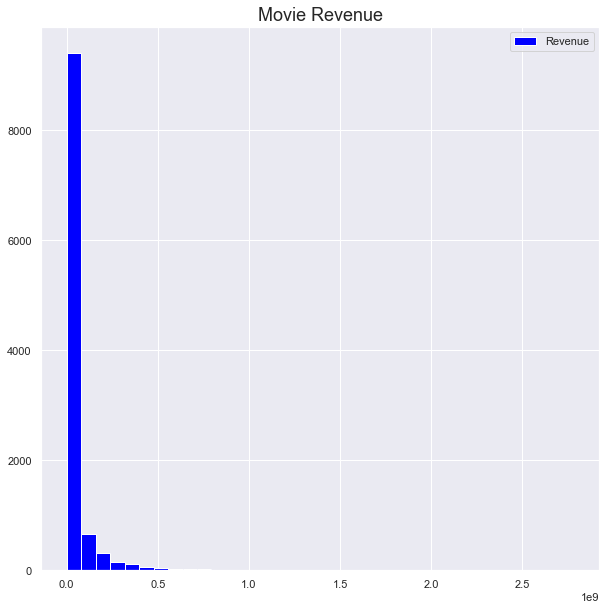

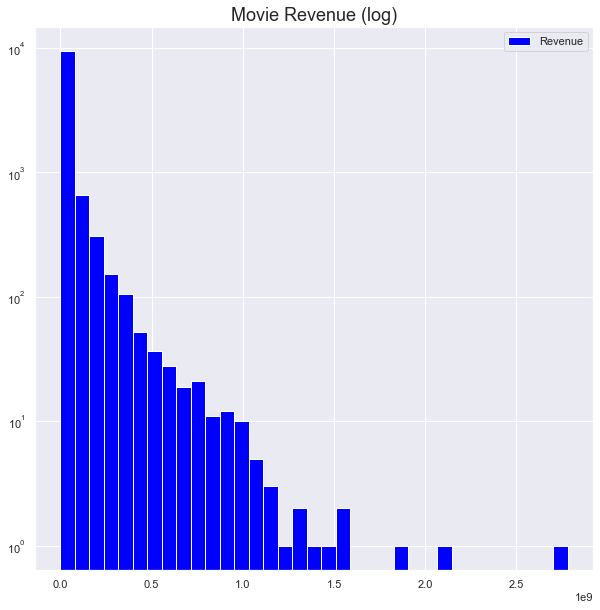

```python
#plotting a histogram for the revenue variable
#I plotted two graphs, one with a linear y-axis, and one with a logarithmic y-axis to see the smaller values on the graph.
plot_func(df['revenue'],'Movie Revenue','Revenue','Blue')
```

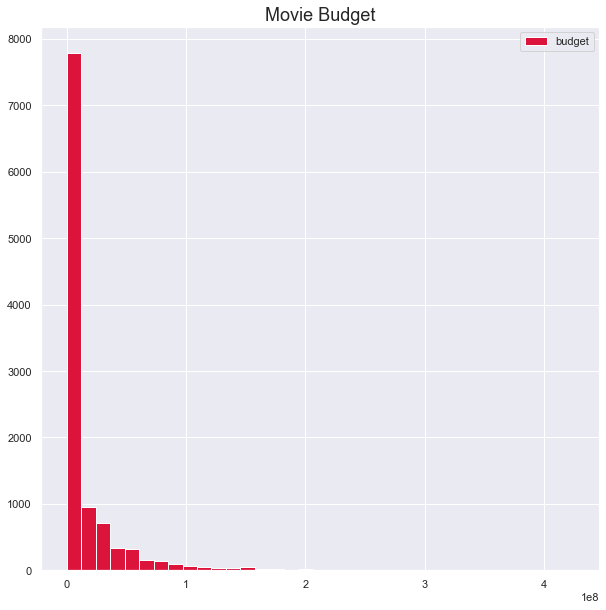

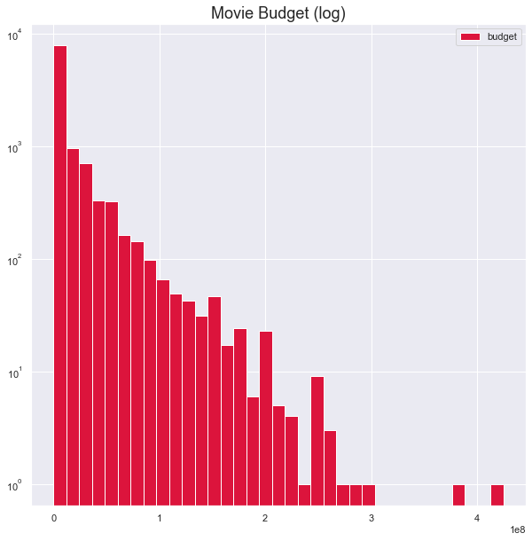

```python
#plotting a histogram for the budget variable
#same with revenvue I plotted two graphs, one with a linear y-axis, and one with a logarithmic y-axis.
plot_func(df['budget'],'Movie Budget','budget','Crimson')
```

```python
r, p = stats.spearmanr(df['budget'], df['revenue'])
print('Spearman correlation coefficient = {}'.format(r))
print('with p-value = {}'.format(p))
```

```
Spearman correlation coefficient = 0.7075835355056855
with p-value = 0.0
```

Firstly, perfoming one of the statistical correlation tests on the two variables. And since the data is non-normally distributed, we use the Spearman correlation test which returns a correlation of 0.707584 (a strong correlation) with a p-value of 0.

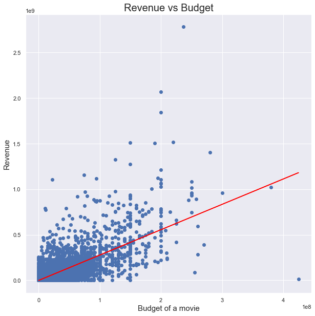

```python
#plotting a graph of the a scatterplot of revenue vs budget with linear regression overlayed atop of it
slope, intercept, r, p, s = linregress(df['budget'], df['revenue'])
plt.figure(figsize = (10,10))
plt.title('Revenue vs Budget', fontsize = 20)
plt.scatter(df['budget'], df['revenue'])
plt.xlabel('Budget of a movie', fontsize = 15)
plt.ylabel('Revenue', fontsize = 15)
plt.plot(df['budget'],slope*df['budget']+intercept,color='red')
plt.show()
```

```python
print('The equation of linear regression is:\nrevenue = {} + {}*budget'.format(round(intercept),round(slope,5)))
print('Spearman correlation coefficient = {}'.format(r))
```

[output not shown]

Although the correlation coefficient of the linear regression is the Pearson correlation coefficient equal to 0.734851131007624, it is close to the Spearman coefficient (0.7075835355056855).

```python
stats.pearsonr(df['budget'], df['revenue'])
```

```
(0.7348511310076239, 0.0)
```

### Which Genres are Most Popular and in What Years?

```python
print(df.info())
```

```
<class 'pandas.core.frame.DataFrame'>
Int64Index: 10842 entries, 0 to 10865
Data columns (total 6 columns):
 #   Column        Non-Null Count  Dtype
---  ------        --------------  -----
 0   popularity    10842 non-null  float64
 1   budget        10842 non-null  int64
 2   revenue       10842 non-null  int64
 3   runtime       10842 non-null  int64
 4   genres        10842 non-null  object
 5   release_year  10842 non-null  int64
dtypes: float64(1), int64(4), object(1)
memory usage: 592.9+ KB
None
```

```python
print(df['genres'].head())
```

```
0    Action|Adventure|Science Fiction|Thriller
1    Action|Adventure|Science Fiction|Thriller
2           Adventure|Science Fiction|Thriller
3     Action|Adventure|Science Fiction|Fantasy
4                        Action|Crime|Thriller
Name: genres, dtype: object
```

```python
print(df['genres'].nunique())
```

```
2039
```

The genre column contains 2039 unique values which are too many variations with many repetitions. Consequently, I will split each genre to a separate row.

```python
#We need to split each genre element to a list containing the different genres as a list
df1 = df.assign(genres=df.genres.str.split('|')).explode('genres').reset_index()
```

```python
#dropping the old index column
df1.drop(columns='index',inplace=True)
```

```python
#creating a numpy array of the years
year_lst=np.sort(np.array(df['release_year'].unique()))
```

```python
#grouping by year and genre to get the mean for each genre in each year
df2=df1.groupby(['release_year','genres'])
```

```python
#creating arrays for year, genre, and popularity to append to a new dataframe
lst=np.array(df2.groups.keys())
genres=np.empty(0,str)
year=np.empty(0,int)
popularity=np.empty(0)
for key in lst.item():
    popularity=np.append(popularity,df2.get_group(key)['popularity'].mean())
    genres=np.append(genres,key[1])
    year=np.append(year,key[0])
```

```python
df_m = pd.DataFrame(list(zip(year,genres,popularity)), columns =['release_year','genres','popularity'])
```

```python
df_m.duplicated().sum()
```

```
0
```

Now, that I have created a dataframe with the mean popularity for each genre in each year with no duplicates, I can query to get the genre with maximum mean popularity in each year.

```python
#running a query for each year to get the genre with max popularity and appending the result to a new dataframe d_n
df_n=pd.DataFrame()
for year in year_lst:
    df_year=df_m.query('release_year=={}'.format(year))
    df_q=df_year.query('popularity=={}'.format(df_year.popularity.max()))
    df_n=pd.concat([df_n,df_q],ignore_index=True)
```

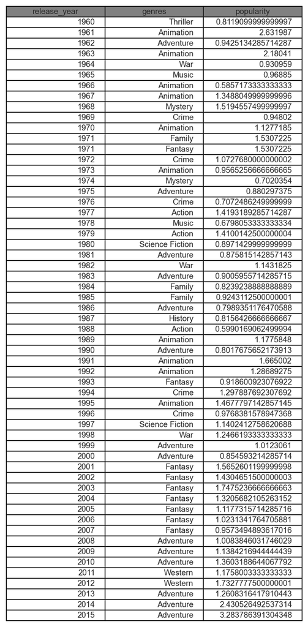

```python
#plotting a table for the most popular genres across all years
fig, ax = plt.subplots(dpi = 150)
plt.axis('off')
plt.table(cellText=df_n.values, colLabels=df_n.columns, loc='center', cellColours = np.repeat('white',171).reshape(57,3), colColours = np.repeat('grey',3))
plt.grid(visible=None)
plt.show()
```

Now, that we have the genre with highest average popularity for each year, I will rank the genres based on average popularity across all years.

```python
#grouping by genre then getting the mean of the remaining columns and sorting by popularity score
df_1=df1.groupby(['genres']).mean().sort_values('popularity')
```

```python
df_1
```

| genres | popularity | budget | revenue | runtime | release_year |
| --- | --- | --- | --- | --- | --- |
| Documentary | 0.181432 | 5.771491e+05 | 2.041107e+06 | 102.651923 | 2008.313462 |
| Foreign | 0.191496 | 1.451435e+06 | 1.520460e+06 | 107.228723 | 2001.398936 |
| TV Movie | 0.270896 | 2.676647e+05 | 2.514970e+05 | 91.982036 | 2004.634731 |
| Horror | 0.465357 | 6.226529e+06 | 1.682281e+07 | 94.424557 | 2001.117288 |
| Music | 0.487321 | 9.438628e+06 | 2.857177e+07 | 105.137255 | 2000.196078 |
| History | 0.575936 | 1.859492e+07 | 3.201179e+07 | 136.206587 | 1997.497006 |
| Western | 0.590615 | 1.897411e+07 | 2.856871e+07 | 117.575758 | 1986.915152 |
| Drama | 0.591495 | 1.188072e+07 | 2.923226e+07 | 110.478151 | 2000.929202 |
| Romance | 0.592082 | 1.253127e+07 | 3.569197e+07 | 106.891355 | 2000.438668 |
| Comedy | 0.592607 | 1.329792e+07 | 3.752624e+07 | 96.745057 | 2000.816240 |
| Mystery | 0.690012 | 1.611927e+07 | 4.021757e+07 | 105.928395 | 1999.850617 |
| War | 0.727683 | 2.089189e+07 | 4.760518e+07 | 127.625926 | 1996.096296 |
| Thriller | 0.741563 | 1.720769e+07 | 4.172842e+07 | 103.247678 | 2001.693498 |
| Crime | 0.744930 | 1.766380e+07 | 4.236866e+07 | 106.917282 | 1999.491137 |
| Family | 0.786668 | 2.335934e+07 | 7.243318e+07 | 89.603574 | 2000.774167 |
| Animation | 0.852182 | 2.315978e+07 | 7.525606e+07 | 68.181688 | 2003.995708 |
| Action | 0.926274 | 2.772782e+07 | 7.279473e+07 | 104.917785 | 2000.056208 |
| Fantasy | 0.992840 | 3.261259e+07 | 9.631366e+07 | 100.736900 | 2000.292576 |
| Science Fiction | 1.001548 | 2.497268e+07 | 7.014056e+07 | 99.419854 | 1999.978845 |
| Adventure | 1.154259 | 3.754369e+07 | 1.131379e+08 | 106.173351 | 1999.388851 |

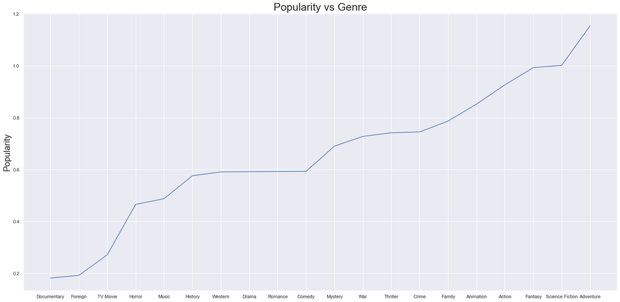

```python
#graphing our result
sns.set_theme()
plt.figure(figsize = (25,12))
plt.plot(df_1.index,df_1['popularity'])
plt.title('Popularity vs Genre', fontsize = 25)
plt.ylabel('Popularity',fontsize = 20)
plt.show()
```

As the graph shows, the least popular genre on average is documentary and the most popular is adventure.

## Conclusions

The variables I investigated in this analysis were budget, revenue, genres, and release year. The focused research area was to study the relationship between the budget of a movie, and its revenue using the appropriate graphs, and confirming the correlation between data with the appropriate statistical tests. Moreover, acquiring the most popular movie genre (that is, the genre with the highest mean popularity score) throughout all years in the data.

### The Correlation between a Movie's Revenue and its Budget

From the regression line plotted atop the scatterplot, there appears to be a positive correlation between a movie's budget and its revenue. Confirming the positive correlation between the budget and revenue requires using a statistical test. The appropriate tests to be used are Pearson's test and Spearman's test. Due to the data being non-normally distributed, I used Spearman's correlation test.

$$\text{Spearman's correlation coefficient: }H_0 = 0.707583$$$$\text{With p-value: }p = 0$$

The correlation coefficient indicates a strong positive correlation between the data. The zero p-value indicates that there is a 0% possibility that the data can be correlated randomly (a false positive). Hence, the results are statistically significant.

With the following regression line equation: $$revenue = -854933 + 2.78168\times budget$$

### The Most Popular Genre across all Years

For this analysis, I managed to determine the genre with the highest mean popularity score for each year in the dataset. And I made a graphical representation of the result in this table.

Furthermore, I determined the most popular and least popular genres on average in this graph.

- Adventure was the most popular genre on average with a popularity score of 1.154259.
- Documentary was the least popular genre on avergae with a popularity score of 0.181432.

.

## Additional Research Areas

Many different research areas may be explored in this dataset, such as:

- The relation between movie runtime and release year
- the relation between movie runtime and revenue
- the relation between popularity and budget

## Limitations

The variation in budget is not sufficient to determine the financial success of a movie, as other factors need to be considered such as the cast and crew, runtime, and genre.

Finally, it is worth noting that getting the most popular genre per year may not be the most useful gauge in this particular situation, as each movie is categorized in different genres. Hence, the genres present in the most popular movies will rise to the top even if it is not the main genre of the film.